# Analysis PS 1

2024-08-31

## 1.1: 2

Q: Verify that the set consisting of two members, 0 and 1, with operations defined by Equations (1.1.1) and (1.1.2), is a field. Then show that it is impossible to define an order on this field that has properties (F), (G), and (H).

(1.1.1)

[figure not shown]

(1.1.2)

[figure not shown]

(F), (G), (H)

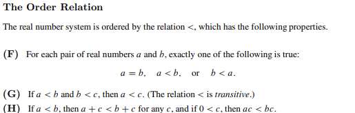

(F), (G), (H) axioms

## 1.1: 4

Q: Show that $\sqrt{p}$ is irrational if $p$ is prime.

## 1.1: 5

Q: Find the suprenum and infimum of each $S$. State whether they are in S.

1. $S = \{ x | x = -\frac{1}{n} + [1 + (-1)^{n}]{n^2}, n \geq1 \}$
2. $S = \{ x | x^2 < 9 \}$
3. $S = \{ x | x^2 \leq 7 \}$
4. $S = \{ x | \space |2x + 1| < 5 \}$
5. $S = \{ x | (x^2 + 1)^{-1} > \frac{1}{2} \}$
6. $S = \{ x | x = \text{rational and }x^2 \leq 7\}$

## 1.1: 7

Q: Show that

1. inf S $\leq$ sup S for any nonempty set S of real numbers, and give necessary and sufficient conditions for equality
2. if S is unbounded then (a) holds if it is interpreted according to Equation (1.1.12) and the definition of Equations (1.1.13) and (1.1.14)

(1.1.12), (1.1.13), (1.1.14)

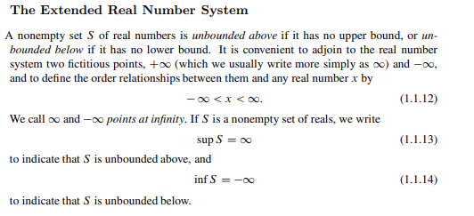

1.1.12, 13, and 14

## 1.1: 8

Let S and T be nonempty sets of real numbers such that every real number is in S or T and if $s \in S$ and $t \in T$, then $s < t$. Prove that there is a unique real number $\beta$ such that every real number less than $\beta$ is in S and every real number greater than $\beta$ is in T. (Also know as Dedekind’s theorem).

## 1.1: 9

Q: Using properties (A) - (H) of real numbers and taking Dedekind’s theorem (Exercise 1.1.8, above) as given, show that every nonempty set U of real numbers that is bounded above has a suprenum.

Hint: Let T be the set of upper bounds of U and S be the set of real numbers that are not upper bounds of U.

## 1.1: 10

Q: Let $S$ and $T$ be nonempty sets of real numbers and define

$$S + T = \{ s + t | s \in S, t \in
T\}$$

1. Show that

(A): $\text{sup(S + T) = sup S + sup T}$ if S and T are bounded above and

(B): $\text{inf(S + T) = inf S + inf T}$ if S and T are bounded below

2. Show that if they are properly interpreted and extended reals, then (A) and (B) hold if S and T are arbitrary nonempty sets of real numbers